# Etude de la Regression linéaire

## Regression linéaire monovariée

Le mot 'régression' a été introduit par Sir Francis Galton (cousin de C. Darwin) alors qu’il étudiait la taille des individus au sein d’une descendance. Il tentait de comprendre pourquoi les grands individus d’une population semblaient avoir des enfants d’une taille plus petite, plus proche de la taille moyenne de la population ; d’où l’introduction du terme “régression”. Dans la suite on va s’intéresser aux données récoltées par Galton.

*Import des données*

```python
#pour avoir les graphiques matplotlib inclus dans le notebook et non affichés dans une fenetre exterieure
%matplotlib inline


import pylab
import numpy as np
import pandas as pd
import matplotlib.pyplot as plt
from matplotlib import rc
import seaborn as sns
from sklearn import linear_model
from os import mkdir, path
from mpl_toolkits.mplot3d import Axes3D
sns.set_context('notebook')
sns.set_style('darkgrid')
sns.set_palette('colorblind')
url = 'http://www.math.uah.edu/stat/data/Galton.txt'

dat = pd.read_csv(url,"\t")

dat.describe()
```

|  | Father | Mother | Height | Kids |
| --- | --- | --- | --- | --- |
| count | 898.000000 | 898.000000 | 898.000000 | 898.000000 |
| mean | 69.232851 | 64.084410 | 66.760690 | 6.135857 |
| std | 2.470256 | 2.307025 | 3.582918 | 2.685156 |
| min | 62.000000 | 58.000000 | 56.000000 | 1.000000 |
| 25% | 68.000000 | 63.000000 | 64.000000 | 4.000000 |
| 50% | 69.000000 | 64.000000 | 66.500000 | 6.000000 |
| 75% | 71.000000 | 65.500000 | 69.700000 | 8.000000 |
| max | 78.500000 | 70.500000 | 79.000000 | 15.000000 |

Créer une colonne supplémentaire appelée “MeanParents” qui contient la taille du parent “moyen”, c’est-à-dire (taillepere + 1.08xtaillemere)/2.

On note Xi la taille du parent moyen pour la famille i et Yi la taille de l'enfant.

On écrit Yi = θ1*Xi + θ0 + εi et on modélise les variables εi comme centrées, indépendantes de même variance σ² inconnue.

```python
col = dat.apply ( lambda row : (row["Father"] + 1.08*row["Mother"]) / 2, axis = 1 )
dat["MeanParents"] = col
```

Les données sont importées d'un fichier dans une table de la forme:

```python
dat.head()
```

|  | Family | Father | Mother | Gender | Height | Kids | MeanParents |
| --- | --- | --- | --- | --- | --- | --- | --- |
| 0 | 1 | 78.5 | 67.0 | M | 73.2 | 4 | 75.43 |
| 1 | 1 | 78.5 | 67.0 | F | 69.2 | 4 | 75.43 |
| 2 | 1 | 78.5 | 67.0 | F | 69.0 | 4 | 75.43 |
| 3 | 1 | 78.5 | 67.0 | F | 69.0 | 4 | 75.43 |
| 4 | 2 | 75.5 | 66.5 | M | 73.5 | 4 | 73.66 |

Affichage des enregistrements sur un repère en 2D:

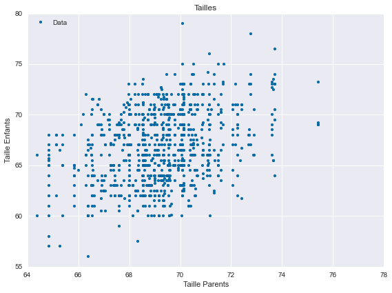

```python
y = dat['Height']
X = dat[['MeanParents']]
n_sample, _ = X.shape

xlabels = 'Taille Parents'
ylabels = 'Taille Enfants'
fig1 = plt.figure(figsize=(8, 6))
plt.xlabel(xlabels)
plt.ylabel(ylabels)
plt.title('Tailles')
plt.plot(X, y, 'o', label="Data", markeredgecolor='k', markeredgewidth=0.1,markersize=4)
axes = plt.gca()
plt.xlim(xmin=64, xmax=78)
plt.ylim(ymin=55, ymax=80)

plt.legend(numpoints=1, loc=2)  # numpoints = 1 for nicer display
plt.tight_layout()
```

*Affichage avec la librairie seaborn (fait exactement la même chose)*

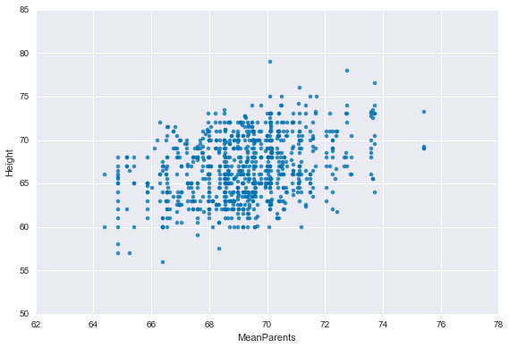

```python
sns.regplot(x='MeanParents', y='Height', data=dat, fit_reg=False)
plt.tight_layout()
```

## Calcul du modèle de régression linéaire

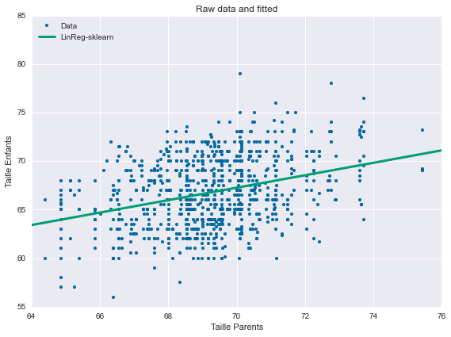

```python
from sklearn import linear_model
skl_linmod0 = linear_model.LinearRegression()
skl_linmod0.fit(X, y)


fig = plt.figure(figsize=(8, 6))
plt.xlim(xmin=64, xmax=76)
plt.ylim(ymin=55, ymax=85)
plt.plot(X, y, 'o', label="Data", markeredgecolor='k', markeredgewidth=0.1,markersize=4)
X_to_predict = np.linspace(64.0, 76.0, num=50).reshape(50, 1)
X_to_predict = pd.DataFrame(X_to_predict, columns=['Kids'])

plt.plot(X_to_predict, skl_linmod0.predict(X_to_predict),
         linewidth=3, label="LinReg-sklearn")
plt.legend(numpoints=1, loc=2)  # numpoints = 1 for nicer display
plt.xlabel(xlabels), plt.ylabel(ylabels)
plt.title('Raw data and fitted')
plt.tight_layout()
plt.show()
```

```python
print "Les paramètres de la droite sont:", "θ0 = ",skl_linmod0.intercept_," et ","θ1 = " , skl_linmod0.coef_[0]
```

```
Les paramètres de la droite sont: θ0 =  22.376205683  et  θ1 =  0.641190379591
```

## Affichage de l'histogramme des résidus

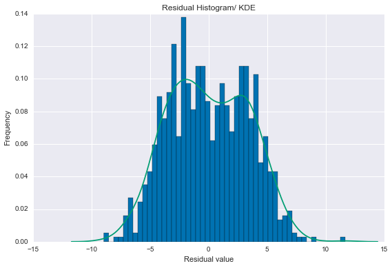

```python
t0 = skl_linmod0.intercept_
t1 = skl_linmod0.coef_

res = y-skl_linmod0.predict(X)

plt.hist(res, bins=50, normed=True)
sns.kdeplot(res)

plt.title('Residual Histogram/ KDE')
ax = plt.gca()
ax.legend_ = None
plt.xlabel('Residual value'), plt.ylabel('Frequency')
plt.tight_layout()
```

Pour chaque estimation on calcule le résidu $\hat{y} - y$ qui est la distance de la valeur estimée $\hat{y}$ de la droite pour un point) avec la valeur réelle ($y$ mesuré de ce même point).

Lorsque la regression linéaire est un bon estimateur, les résidus ont une répartion gaussienne centrée en 0, il correspondent à un bruit blanc qui peut être dû au procédé de prise de mesure.

On observe ici une répartition bimodale. L'erreur d'estimation augmente autour des valeurs de résidus égales à -3 et +3. Les parents plus grands que la moyenne ont des enfants qui tendent à ne pas suivre le modèle linéaire mais à se rapprocher de la moyenne des tailles des enfants de leur âge. Le même phénomène s'observe pour les parents plus petits que la moyenne. Il semble qu'un facteur biologique soit prépondérant et tire les tailles vers la moyenne de la population.

```python
###Inversion des variables X et Y
```

On calcule le modèle de regression linéaire le plus vraissemblable (Ce modèle correspond à la droite pour laquelle on calcule une répartition des résidus la plus Gaussienne possible) pour représenter à l'inverse la taille moyenne des parents en fonction de la taille de leur enfant.

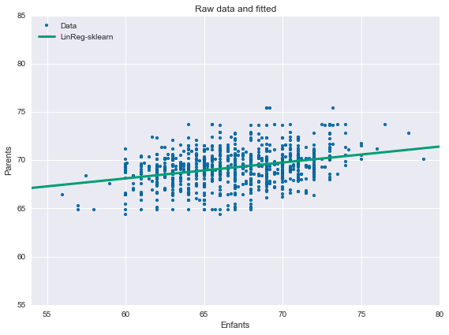

```python
X2 = dat[['Height']]
Y2 = dat['MeanParents']
xlabels = 'Enfants'
ylabels = 'Parents'
skl_linmod0_1 = linear_model.LinearRegression()
skl_linmod0_1.fit(X2, Y2)
fig = plt.figure(figsize=(8, 6))
plt.xlim(xmin=54, xmax=80)
plt.ylim(ymin=55, ymax=85)
plt.plot(X2, Y2 , 'o', label="Data", markeredgecolor='k', markeredgewidth=0.1,markersize=4)
X_to_predict = np.linspace(54.0, 80.0, num=50).reshape(50, 1)
X_to_predict = pd.DataFrame(X_to_predict, columns=['Kids'])

plt.plot(X_to_predict, skl_linmod0_1.predict(X_to_predict),
         linewidth=3, label="LinReg-sklearn")
plt.legend(numpoints=1, loc=2)  # numpoints = 1 for nicer display
plt.xlabel(xlabels), plt.ylabel(ylabels)
plt.title('Raw data and fitted')
plt.tight_layout()
```

```python
print "Les paramètres de la droite sont:", "θ0 = ",skl_linmod0_1.intercept_," et ","θ1 = " , skl_linmod0_1.coef_[0]
```

```
Les paramètres de la droite sont: θ0 =  58.2039351454  et  θ1 =  0.165038310213
```

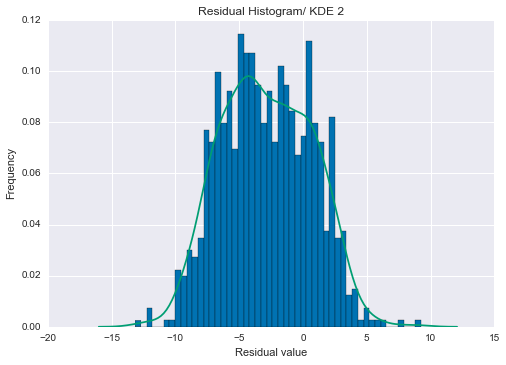

```
Comparaison des valeurs
 a0 is  58.2039351454 and Calc a0 is   58.2039351454
 a1 is  [ 0.16503831] and Calc a1 is   0.165038310213
```

```python
res = y-skl_linmod0_1.predict(X)

plt.hist(res, bins=50, normed=True)
sns.kdeplot(res)

plt.title('Residual Histogram/ KDE 2 ')
ax = plt.gca()
ax.legend_ = None
plt.xlabel('Residual value'), plt.ylabel('Frequency')

plt.show()

a0 = skl_linmod0_1 .intercept_
a1 = skl_linmod0_1 .coef_

moy_x = X.mean()
moy_y = y.mean()

calc_a0 = moy_x + (moy_y/moy_x )*(np.var(X)/np.var(y))*(t0-moy_y)
calc_a1 = np.var(X)/np.var(y)*t1

print "Comparaison des valeurs"
print " a0 is " , a0 , "and Calc a0 is  ", calc_a0['MeanParents']
print " a1 is " , a1 , "and Calc a1 is  ", calc_a1['MeanParents']
```

Il est intéressant de constater qu'un rapport linéaire entre une variable x et une variable y ne presume pas en réalité de la linéarité du rapport inverse, entre y et x. Tout dépend de la répartition des points autour de la droite.

# Regression linéaire multivariée

On va modeliser ici la taille des enfants en fonction de deux varaibles, la taille de la mere X1 et la taille du père X2

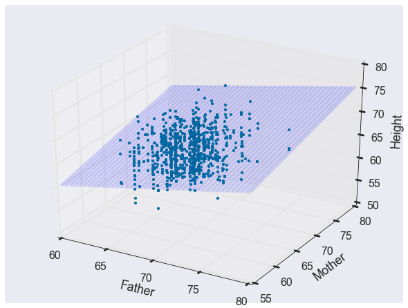

```python
###################Reg lin en 3D#########################################


# Fit regression model
X = dat[['Father', 'Mother']]
y = dat['Height']
skl_linmod1 = linear_model.LinearRegression()
skl_linmod1.fit(X, y)

XX = np.arange(60, 80, 0.1)
YY = np.arange(55, 80, 0.1)
xx, yy = np.meshgrid(XX, YY)
zz = skl_linmod1.coef_[0]* xx + skl_linmod1.coef_[1] * yy + skl_linmod1.intercept_

fig = plt.figure(figsize=(8, 6))

sns.set_context("poster")
sns.set_palette("colorblind")
ax = Axes3D(fig)

ax.plot(X['Father'], X['Mother'], y, 'o',markeredgewidth=0.1,markersize=4)
ax.set_zlim(50, 80)
ax.set_xlabel('Father')
ax.set_ylabel('Mother')
ax.set_zlabel('Height')


ax.plot_wireframe(xx, yy, zz, rstride=5, cstride=5, alpha=0.1)

plt.show()
```

```python
print "Les valeurs des paramètres du modèle sont l'offset sur l'axe des z (Height) θ0= {:.2f}".format(skl_linmod1.intercept_),  "la pente du plan par rapport à l'axe Father θ1= {:.2f}".format(skl_linmod1.coef_[0])," la pente du plan par rapport à l'axe Mother θ2= {:.2f}".format(skl_linmod1.coef_[1])
```

```
Les valeurs des paramètres du modèle sont l'offset sur l'axe des z (Height) θ0= 22.31 la pente du plan par rapport à l'axe Father θ1= 0.38  la pente du plan par rapport à l'axe Mother θ2= 0.28
```

On constate sur l'échantillon que la taille du père a une influence un peu plus importante que la taille de la mère sur la taille de l'enfant.

Calcul des residus:

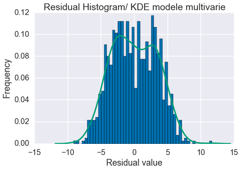

```python
res = y-skl_linmod1.predict(X)
res2= (y-skl_linmod1.predict(X)).dot(y-skl_linmod1.predict(X))

fig2 = plt.figure(figsize=(7, 5))

plt.hist(res, bins=50, normed=True)
sns.kdeplot(res)
plt.title('Residual Histogram/ KDE modele multivarie ')
ax = plt.gca()
ax.legend_ = None
plt.xlabel('Residual value'), plt.ylabel('Frequency')
plt.tight_layout()
plt.show()
```

Calcul de $||r||²$

```python
print "Somme des carrés des résidus = {:.2f}".format(res2)
```

```
Somme des carrés des résidus = 10261.13
```

Nous constatons à nouveau une bimodalité dans la répartition des résidus.

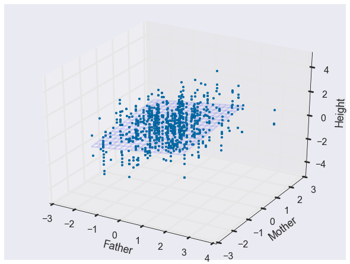

```python
from sklearn import preprocessing


X_norm = (X - X.mean()) / np.std(X)
y_norm = (y - y.mean()) / np.std(y)

X_norm.head()
y_norm.head()

skl_linmod2 = linear_model.LinearRegression()
skl_linmod2.fit(X_norm, y_norm)

XX = np.arange(-2, 2, 0.05)
YY = np.arange(-2, 2, 0.05)
xx, yy = np.meshgrid(XX, YY)
zz = skl_linmod2.coef_[0]* xx + skl_linmod2.coef_[1] * yy + skl_linmod2.intercept_

fig = plt.figure(figsize=(8, 6))

sns.set_context("poster")
sns.set_palette("colorblind")
ax = Axes3D(fig)

ax.plot(X_norm['Father'], X_norm['Mother'], y_norm, 'o',markeredgewidth=0.1,markersize=4)
ax.set_zlim(-5, 5)
ax.set_xlabel('Father')
ax.set_ylabel('Mother')
ax.set_zlabel('Height')


ax.plot_wireframe(xx, yy, zz, rstride=5, cstride=5, alpha=0.1)

plt.show()
```

```python
print "Les valeurs des paramètres du modèle sont l'offset sur l'axe des z (Height) θ0= {:.4f}".format(skl_linmod2.intercept_),  "la pente du plan par rapport à l'axe Father θ1= {:.4f}".format(skl_linmod2.coef_[0])," la pente du plan par rapport à l'axe Mother θ2= {:.4f}".format(skl_linmod2.coef_[1])
```

```
 Les valeurs des paramètres du modèle sont l'offset sur l'axe des z (Height) θ0= 0.0000 la pente du plan par rapport à l'axe Father θ1= 0.2619  la pente du plan par rapport à l'axe Mother θ2= 0.1824
```